# Dynamic Linear Model

Time Series

Dynamic Linear Model for Time Series Data

Yeongeun Jeon , Jung In Seo  
05-29-2020

- Data 출처 : [Data Mining for Business Analytics](https://www.dataminingbook.com/book/r-edition)에서 사용한 미국 철도 회사 “Amtrak”에서 수집한 1991년 1월~2004년 3월까지 매달 환승 고객 수

# **Introduction**

- Dynamic linear model (DLM)은 상태공간모형 (state space model)에서 선형성 (linear)과 정규분포 (Gaussian distribution)를 가정하는 모형이다.
- DLM은 비정상성 시계열을 모형화하는 데 유용하며 시간에 따라 변하는 회귀계수를 가지는 선형회귀모형의 일반화 형태이다.
- DLM은 다음과 같다.

$$\begin{aligned}
Y_{t}&=F_{t}\theta_{t}+v_{t},~~~~~~~v_{t}\sim N_{m}(0,V_{t}), \\
\theta_{t}&=G_{t}\theta_{t-1}+\omega_{t},~~~\omega_{t}\sim N_{p}(0,W_{t}).
\end{aligned}$$

- 첫번째는 관측방정식, 두번째는 상태방정식이다.
  - $Y_{t}$ : 시점 $t$에서 관측값
  - $\theta_{t}$ : 시점 $t$에서 시스템의 관측할 수 없는 상태 (시계열에서 추세, 계절성 등 성분이 상태가 될 수 있다.)
  - $F_{t}$, $G_{t}$ : 알고 있는 행렬
  - $v_{t}$, $\omega_{t}$ : 오차
  - $V_{t}$, $W_{t}$ : 알고 있는 공분산 행렬
- 수식을 보면 시점 $t$에 의존하여 시간에 따라 회귀 계수가 변화할 수 있다.
- Ridership on Amtrak Trains(미국 철도 회사 “Amtrak”에서 수집한 1991년 1월~2004년 3월까지 매달 환승 고객 수) 예제를 이용하여 DLM이 실제 데이터에 어떻게 적용되는지 설명한다.

# **Dynamic linear model**

```
# Data 불러오기기
pacman::p_load("data.table")

  Amtrak.data <- fread(paste(getwd(),"Amtrak.csv", sep="/"))
```

```
ridership.ts <- ts(Amtrak.data$Ridership, start=c(1991,1), end=c(2004,3), freq=12)
train.ts     <- window(ridership.ts,start=c(1991,1), end=c(2001,3))
valid.ts     <- window(ridership.ts,start=c(2001,4))
nValid       <- length(valid.ts)
```

## **정규성 확인**

- DLM은 선형성과 정규성을 가정하기 때문에 데이터가 정규분포를 따르는지 확인이 필요하다.

### **Entire Data**

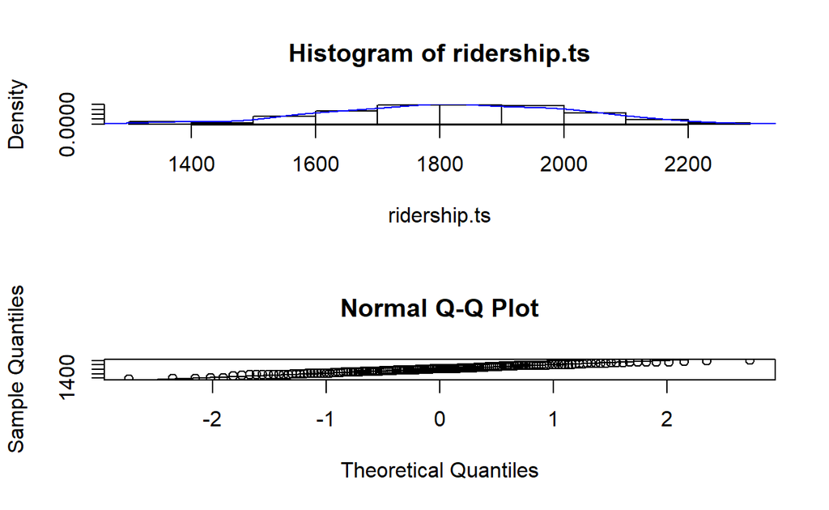

```
par(mfrow=c(2,1))
hist(ridership.ts, prob=TRUE, 12)
lines(density(ridership.ts), col="blue")
qqnorm(ridership.ts)
qqline(ridership.ts)
```

### **Training Data**

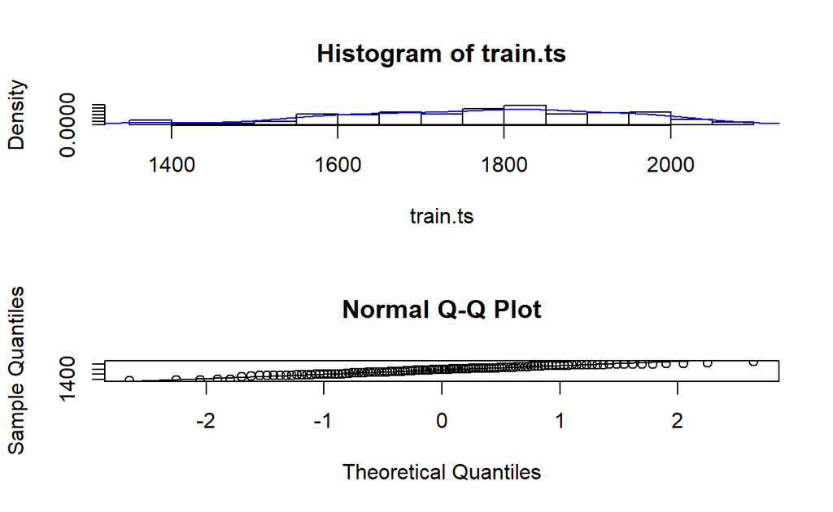

```
par(mfrow=c(2,1))
hist(train.ts, prob=TRUE, 12)
lines(density(train.ts), col="blue")
qqnorm(train.ts)
qqline(train.ts)
```

- 두 그래프를 보면 Ridership은 정규분포를 따른다는 것을 알 수 있다.

## **분해 (Decomposition)**

- 시계열은 다양한 패턴으로 나타날 수 있다. (추세, 계절성 등)
- 시계열을 몇 가지 성분으로 나누는 작업은 시계열을 이해하는데 종종 도움이 된다.
- DLM은 가법 분해 (관측된 시계열을 다른 성분들의 합으로 표현)를 사용한다.
- R 함수 `decompose()`를 이용하여 데이터를 추세와 계절성, 불규칙 성분으로 나눌 수 있다.

### **Entire Data**

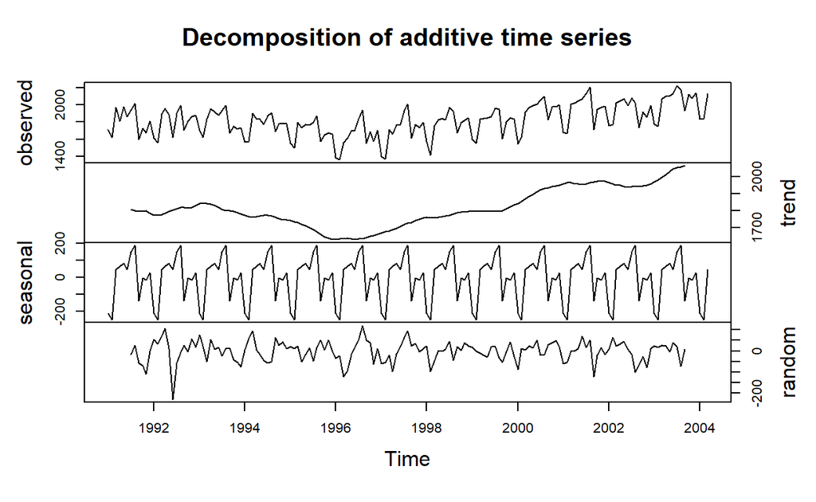

```
par(mfrow=c(1,1))
plot(decompose(ridership.ts), yax.flip=TRUE)
```

### **Training Data**

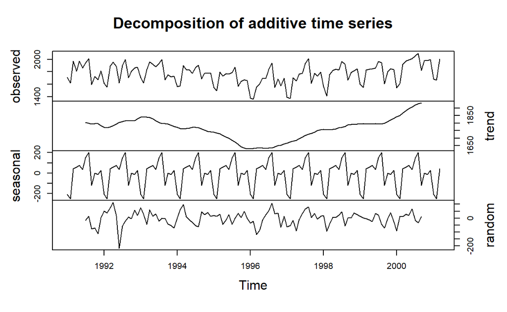

```
plot(decompose(train.ts), yax.flip=TRUE)
```

## **모형 설정**

- Polynomial DLM은 시계열의 추세를 설명하는 데 가장 흔하게 사용된다.
- 가장 간단한 모형은 local level model이고 모형식은 다음과 같다.

$$\begin{aligned}
Y_{t}&=\mu_{t}+v_{t},~~~~~~~v_{t}\sim N_{m}(0,V), \\
\mu_{t}&=\mu_{t-1}+\omega_{t},~~~\omega_{t}\sim N_{p}(0,W).
\end{aligned}$$

- Local level model은 random walk와 noise가 더해진 형태로 뚜렷한 추세나 계절적 변동을 보이지 않는 시계열에 적절하다.
- `dlm` package에 `dlmModPoly(1)`은 local level model이다.
- Local level model이 시간에 따라 추세의 수준만 변하는 모형이라면, local linear trend model은 시간에 따라 추세의 수준 뿐만 아니라 추세의 기울기 또한 변하는 모형을 의미한다.

$$\begin{aligned}
Y_{t}&=\mu_{t}+v_{t},~~~~~~~v_{t}\sim N_{m}(0,V), \\
\mu_{t}&=\mu_{t-1}+\beta_{t-1}+\omega_{t,1},~~~\omega_{t,1}\sim N_{p}(0,\sigma^2_{\mu}),\\
\beta_{t}&=\beta_{t-1}+\omega_{t,2},~~~\omega_{t,2}\sim N_{p}(0,\sigma^2_{\beta}).
\end{aligned}$$

- `dlm` package에 `dlmModPoly(2)`은 local linear trend model이다.
- Local level model과 local linear trend model이 추세 성분과 관련된 모형이라면 계절성 성분과 관련된 계절성 DLM도 있다.
- 예제는 추세와 계절성을 동시에 가지고 있는 데이터로써 local linear trend model과 계절성 DLM (주기 12)이 더해진 모형으로 설정하였다.

```
library(dlm)

model1 <- function(p){

  mod               <- dlmModPoly(2) +  # Local Trend Linear
                       dlmModSeas(12) # 주기 12
  V(mod)            <- exp(p[1])
  diag(W(mod))[1:3] <- exp(p[2:4])

  return(mod)
}
```

## **모수 추정**

- MLE 방법으로 설정된 모형에 대한 모수를 추정한다. 이 때 모수는 관측값 오차의 분산, 상태 오차의 분산이다.
- `dlm` package에 `dlmMLE()`을 이용하여 MLE를 얻을 수 있다.
- 모수의 수렴성을 확인하고 추정된 모수를 DLM에 적합시켰다.

```
mle1      <- dlmMLE(train.ts, parm=c(0.1,0.1,1,1), build=model1 )   # Estimation parameter through MLE. Parameter=Variance of error
ifelse(mle1$convergence==0, print("converge"), print("did not converge") ) # Check Convergence
```

```
[1] "converge"
```

```
[1] "converge"
```

```
modelfit1 <- model1(mle1$par)  # Fitting the DLM
```

```
V(modelfit1)
```

```
        [,1]
[1,] 1413.91
```

- 추정된 관측값 오차의 분산은 1413.91이다.

```
W(modelfit1)
```

```
          [,1]      [,2]     [,3] [,4] [,5] [,6] [,7] [,8] [,9] [,10]
 [1,] 1143.988 0.0000000  0.00000    0    0    0    0    0    0     0
 [2,]    0.000 0.2040261  0.00000    0    0    0    0    0    0     0
 [3,]    0.000 0.0000000 14.47867    0    0    0    0    0    0     0
 [4,]    0.000 0.0000000  0.00000    0    0    0    0    0    0     0
 [5,]    0.000 0.0000000  0.00000    0    0    0    0    0    0     0
 [6,]    0.000 0.0000000  0.00000    0    0    0    0    0    0     0
 [7,]    0.000 0.0000000  0.00000    0    0    0    0    0    0     0
 [8,]    0.000 0.0000000  0.00000    0    0    0    0    0    0     0
 [9,]    0.000 0.0000000  0.00000    0    0    0    0    0    0     0
[10,]    0.000 0.0000000  0.00000    0    0    0    0    0    0     0
[11,]    0.000 0.0000000  0.00000    0    0    0    0    0    0     0
[12,]    0.000 0.0000000  0.00000    0    0    0    0    0    0     0
[13,]    0.000 0.0000000  0.00000    0    0    0    0    0    0     0
      [,11] [,12] [,13]
 [1,]     0     0     0
 [2,]     0     0     0
 [3,]     0     0     0
 [4,]     0     0     0
 [5,]     0     0     0
 [6,]     0     0     0
 [7,]     0     0     0
 [8,]     0     0     0
 [9,]     0     0     0
[10,]     0     0     0
[11,]     0     0     0
[12,]     0     0     0
[13,]     0     0     0
```

- $W$ 는 상태 오차의 공분산 행렬이다.
- 1열은 수준, 2열은 기울기, 3열에서 13열은 계절성과 관련되어있다.
- 추세의 수준 오차의 분산은 1143.988, 추세의 기울기 오차의 분산은 0.2040261, 계절성 오차의 분산은 14.47867이다.

## **상태 추정**

- DLM은 kalman filtering과 smoothing방법을 이용하여 관측할 수 없는 상태 $\theta_{t}$를 추정한다.
  - Kalman filtering : 과거와 현재의 관측값($y_{1},\ldots,y_{t}$)을 이용하여 상태의 현재값($\theta_{t}$)을 추정
  - Kalman smoothing : 주어진 모든 관측값 ($y_{1},\ldots,y_{T}$)을 이용하여 상태의 과거값($\theta_{t}$)을 추정
- 즉, filtering과 smoothing방법은 상태($\theta_{t}$)를 추정하는 방법이다.

### **Kalman filtering**

- `dlm` package의 `dlmFilter()`를 이용하여 kalman filtering을 수행할 수 있다.

```
filtering <- dlmFilter(train.ts, modelfit1)
str(filtering,1)
```

```
List of 9
 $ y  : Time-Series [1:123] from 1991 to 2001: 1709 1621 1973 1812 1975 ...
 $ mod:List of 10
  ..- attr(*, "class")= chr "dlm"
 $ m  : Time-Series [1:124, 1:13] from 1991 to 2001: 0 263 1477 2060 2237 ...
 $ U.C:List of 124
 $ D.C: num [1:124, 1:13] 3162.3 26.6 23.4 21.4 19.3 ...
 $ a  : Time-Series [1:123, 1:13] from 1991 to 2001: 0 394 2049 2636 2683 ...
 $ U.R:List of 123
 $ D.R: num [1:123, 1:13] 10916 8163 5192 4498 4165 ...
 $ f  : Time-Series [1:123] from 1991 to 2001: 0 263 1954 2542 2578 ...
 - attr(*, "class")= chr "dlmFiltered"
```

- y : observation
- mod : model
- m : the mean of the filtered distributions
- U.C/D.C : singular value decomposition of variance of the filtered distributions
- a : the mean of the predictive distributions
- U.R/D.R : singular value decomposition of variance of the predictive distributions
- f : one-step-ahead forecast

```
filtering$y
```

```
          Jan      Feb      Mar      Apr      May      Jun      Jul
1991 1708.917 1620.586 1972.715 1811.665 1974.964 1862.356 1939.860
1992 1614.827 1557.088 1891.223 1955.981 1884.714 1623.042 1903.309
1993 1705.259 1618.535 1836.709 1957.043 1917.185 1882.398 1933.009
1994 1563.365 1573.959 1902.639 1833.888 1831.049 1775.755 1867.508
1995 1548.415 1496.925 1798.316 1732.895 1772.345 1761.207 1791.655
1996 1381.758 1360.852 1558.575 1608.420 1696.696 1693.183 1835.516
1997 1396.588 1371.690 1707.522 1654.604 1762.903 1775.800 1934.219
1998 1570.330 1412.691 1754.641 1824.932 1843.289 1825.964 1968.172
1999 1599.427 1548.804 1832.333 1839.720 1846.498 1864.852 1965.743
2000 1541.660 1616.928 1919.538 1971.493 1992.301 2009.763 2053.996
2001 1683.148 1663.404 2007.928
          Aug      Sep      Oct      Nov      Dec
1991 2013.264 1595.657 1724.924 1675.667 1813.863
1992 1996.712 1703.897 1810.000 1861.601 1875.122
1993 1996.167 1672.841 1752.827 1720.377 1734.292
1994 1906.608 1685.632 1778.546 1775.995 1783.350
1995 1874.820 1571.309 1646.948 1672.631 1656.845
1996 1942.573 1551.401 1686.508 1576.204 1700.433
1997 2008.055 1615.924 1773.910 1732.368 1796.626
1998 1921.645 1669.597 1791.474 1816.714 1846.754
1999 1949.002 1607.373 1803.664 1850.309 1836.435
2000 2097.471 1823.706 1976.997 1981.408 2000.153
2001
```

```
filtering$m
```

```
              [,1]         [,2]         [,3]         [,4]
Dec 1990    0.0000   0.00000000    0.0000000    0.0000000
Jan 1991  262.9201 131.45255272 1445.9782703 -131.4525527
Feb 1991 1476.8170 571.74869261  143.7352725  803.8625714
Mar 1991 2060.3500 576.13321930  -87.6359341  136.3373907
Apr 1991 2237.2100 446.14979550 -425.4996685  181.5776531
May 1991 2385.8677 362.60860175 -410.8614818 -211.6142199
Jun 1991 2401.0946 278.08632437 -538.6793347 -148.0882208
Jul 1991 2424.6579 223.86256634 -484.7468721 -338.4502888
Aug 1991 2455.6739 187.47536594 -442.3652688 -328.3461270
Sep 1991 2322.8861 133.37877892 -727.1449006 -176.3051709
Oct 1991 2262.8372 103.85035440 -537.8560730 -563.3153490
Nov 1991 2199.5074  80.59240254 -523.7855314 -393.9988782
Dec 1991 2187.4420  68.76012370 -373.5454858 -442.9986408
Jan 1992 1758.4610  -7.79796175 -143.4933161   47.4633017
Feb 1992 1764.1211  -6.52855213 -212.3778196 -146.0151113
Mar 1992 1754.4566  -6.74330687  138.1708580 -211.4931427
Apr 1992 1850.1970  -0.71397510   59.7619129  106.0490927
May 1992 1784.2186  -4.31300134  129.6817089   80.8835588
Jun 1992 1682.8321  -9.52788355  -16.4587139  161.4112532
Jul 1992 1726.6984  -6.68851443  152.7877762  -33.9613840
Aug 1992 1752.0489  -4.99112401  230.3685279  142.2780734
Sep 1992 1818.3872  -1.21683610 -146.3164463  206.9681827
Oct 1992 1836.3837  -0.20048676  -34.9567937 -152.6195303
Nov 1992 1890.9173   2.69491388  -53.7386506  -52.9127630
Dec 1992 1858.6399   0.84468898   32.0863375  -42.2652516
Jan 1993 1853.2098   0.46507386 -145.2878076   34.2870337
Feb 1993 1844.8289   0.07146788 -221.5446790 -143.8436169
Mar 1993 1779.4310  -2.40382931   93.2331456 -208.9065938
Apr 1993 1832.8733  -0.43847445   93.5328089   81.8687946
May 1993 1813.8261  -1.07437031  113.5513215   97.3828603
Jun 1993 1881.3442   1.24290741  -36.4930956   99.2892044
Jul 1993 1846.7681   0.03774376  105.8452432  -29.0358588
Aug 1993 1821.4646  -0.81391069  188.5719385  111.1222394
Sep 1993 1825.7177  -0.64362476 -155.6499781  187.5167950
Oct 1993 1808.6432  -1.19601945  -46.8235668 -152.2283494
Nov 1993 1783.1737  -2.01246514  -49.5124028  -41.7682310
Dec 1993 1740.1727  -3.39252386   16.5478228  -40.9726284
Jan 1994 1724.6768  -3.84210018 -154.8227923   19.2139087
Feb 1994 1761.5921  -2.61091076 -211.5445695 -160.3479027
```

[output cut: 445 more lines]

```
Jan 2000   45.690860
Feb 2000   46.399209
Mar 2000   76.851223
Apr 2000   34.429441
May 2000  152.908108
Jun 2000  200.538349
Jul 2000 -125.687083
Aug 2000   -1.441111
Sep 2000  -10.008935
Oct 2000   30.282087
Nov 2000 -209.753593
Dec 2000 -248.607200
Jan 2001   45.052858
Feb 2001   50.238996
Mar 2001   76.282143
```

- $m_{0}$ (초기값) 시점부터 $m_{t}$ 시점까지 보여지므로 총 $t+1$ 개이며 1990년 12월이 1행이다.
- 1열은 추세의 수준 ($\mu_{t}$), 2열은 추세의 기울기 ($\beta_{t}$), 3열부터 13열은 계절성에 대한 추정이다.

```
filtering$a
```

```
              [,1]         [,2]         [,3]         [,4]
Jan 1991    0.0000   0.00000000    0.0000000    0.0000000
Feb 1991  394.3727 131.45255272 -131.4527431 1445.9782703
Mar 1991 2048.5657 571.74869261  -94.7600952  143.7352725
Apr 1991 2636.4832 576.13321930  -94.3943989  -87.6359341
May 1991 2683.3597 446.14979550 -105.2246146 -425.4996685
Jun 1991 2748.4763 362.60860175 -112.1851875 -410.8614818
Jul 1991 2679.1810 278.08632437 -119.2269271 -538.6793347
Aug 1991 2648.5205 223.86256634 -123.7444070 -484.7468721
Sep 1991 2643.1493 187.47536594 -126.7757598 -442.3652688
Oct 1991 2456.2649 133.37877892 -131.2817450 -727.1449006
Nov 1991 2366.6876 103.85035440 -133.7417119 -537.8560730
Dec 1991 2280.0998  80.59240254 -135.6790162 -523.7855314
Jan 1992 2256.2021  68.76012370  277.6717566 -373.5454858
Feb 1992 1750.6630  -7.79796175 -223.9327324 -143.4933161
Mar 1992 1757.5925  -6.52855213  140.5805109 -212.3778196
Apr 1992 1747.7133  -6.74330687  -14.6581422  138.1708580
May 1992 1849.4830  -0.71397510  176.0972833   59.7619129
Jun 1992 1779.9056  -4.31300134   52.1462483  129.6817089
Jul 1992 1673.3042  -9.52788355  115.1060916  -16.4587139
Aug 1992 1720.0099  -6.68851443  207.7597723  152.7877762
Sep 1992 1747.0578  -4.99112401 -196.6576101  230.3685279
Oct 1992 1817.1703  -1.21683610  -48.5177751 -146.3164463
Nov 1992 1836.1833  -0.20048676  -92.3699141  -34.9567937
Dec 1992 1893.6123   2.69491388   56.7680644  -53.7386506
Jan 1993 1859.4846   0.84468898 -141.9348129   32.0863375
Feb 1993 1853.6749   0.46507386 -217.1921076 -145.2878076
Mar 1993 1844.9004   0.07146788  123.4531748 -221.5446790
Apr 1993 1777.0272  -2.40382931   68.4305151   93.2331456
May 1993 1832.4348  -0.43847445  121.8406562   93.5328089
Jun 1993 1812.7517  -1.07437031  -66.9699279  113.5513215
Jul 1993 1882.5871   1.24290741  121.7519596  -36.4930956
Aug 1993 1846.8058   0.03774376  199.8253062  105.8452432
Sep 1993 1820.6507  -0.81391069 -157.9001088  188.5719385
Oct 1993 1825.0741  -0.64362476  -39.5275942 -155.6499781
Nov 1993 1807.4472  -1.19601945  -38.7357560  -46.8235668
Dec 1993 1781.1612  -2.01246514   34.7363091  -49.5124028
Jan 1994 1736.7802  -3.39252386 -150.2400144   16.5478228
Feb 1994 1720.8347  -3.84210018 -225.9627914 -154.8227923
Mar 1994 1758.9812  -2.61091076   80.8026267 -211.5445695
```

[output cut: 441 more lines]

```
Jan 2000   46.8772829
Feb 2000   45.0473346
Mar 2000   76.2354309
Apr 2000   33.4977599
May 2000  152.6296932
Jun 2000  199.6566585
Jul 2000 -125.1034734
Aug 2000   -1.1157967
Sep 2000  -10.5145180
Oct 2000   29.7119397
Nov 2000 -210.1455943
Dec 2000 -248.4848555
Jan 2001   46.1702258
Feb 2001   50.4736000
Mar 2001   75.8110839
```

- $a_{t}=G_{t}m_{t-1}$로 $\theta_{t}$에 대한 추정이다.

```
filtering$f
```

```
          Jan      Feb      Mar      Apr      May      Jun      Jul
1991    0.000  262.920 1953.806 2542.089 2578.135 2636.291 2559.954
1992 2533.874 1526.730 1898.173 1733.055 2025.580 1832.052 1788.410
1993 1717.550 1636.483 1968.354 1845.458 1954.275 1745.782 2004.339
1994 1586.540 1494.872 1839.784 1887.641 1871.495 1713.669 1884.130
1995 1624.354 1524.911 1815.238 1795.564 1769.381 1657.413 1840.032
1996 1486.364 1371.718 1670.654 1584.176 1612.430 1569.849 1742.445
1997 1469.337 1383.042 1660.411 1678.985 1693.031 1657.212 1833.422
1998 1564.790 1527.906 1756.789 1737.385 1827.893 1775.680 1920.357
1999 1620.497 1549.632 1851.400 1837.085 1873.979 1803.831 1959.681
2000 1619.308 1518.112 1872.280 1899.065 1970.615 1941.086 2099.478
2001 1766.339 1682.651 1967.525
          Aug      Sep      Oct      Nov      Dec
1991 2524.776 2516.373 2324.983 2232.946 2144.421
1992 1927.770 1550.400 1768.653 1743.813 1950.380
1993 2046.631 1662.751 1785.547 1768.711 1815.898
1994 1951.432 1581.900 1745.575 1755.732 1821.999
1995 1879.097 1565.207 1668.964 1649.227 1704.771
1996 1867.054 1601.545 1668.318 1679.321 1651.080
1997 1970.264 1667.501 1743.867 1739.239 1786.765
1998 2026.409 1630.716 1767.309 1755.758 1844.312
1999 2021.165 1658.950 1743.359 1759.353 1860.963
2000 2122.863 1784.138 1932.182 1950.244 2009.787
2001
```

- $f_{t}=F_{t}a_{t}=F_{t}G_{t}m_{t-1}$로 $Y_{t}$에 대한 추정이다.
- $f$의 첫번째 값이 0인 이유는 $E(Y_{1}|y_{0})$은 계산될 수 없기에 초기값으로 대체하였다. 그래서 첫번째 값은 버려야한다.

#### **Plot estimation for filtering**

- 다음은 추정된 관측값과 실제 관측값에 대한 그래프이다.

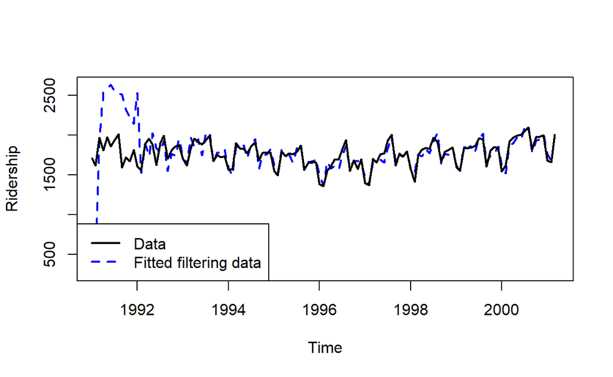

```
# Plot estimation for filtering
# Fittited model

plot(dropFirst(filtering$f), col="blue", lwd=2, lty=2, ylab="Ridership")
lines(train.ts ,lty=1, lwd=2, col="black")
legend("bottomleft", legend=c("Data", "Fitted filtering data"), col=c("black", "blue"), lty=1:2, lwd=2)
```

- 다음은 kalman filtering에 의해 추정된 추세의 수준과 기울기에 대한 그래프이다.
- 추정된 추세의 수준과 기울기는 시간에 따라 변화하는 것을 알 수 있다.

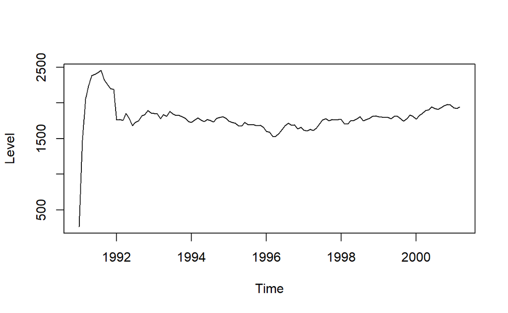

```
plot(dropFirst(filtering$m[,1]), ylab="Level")
```

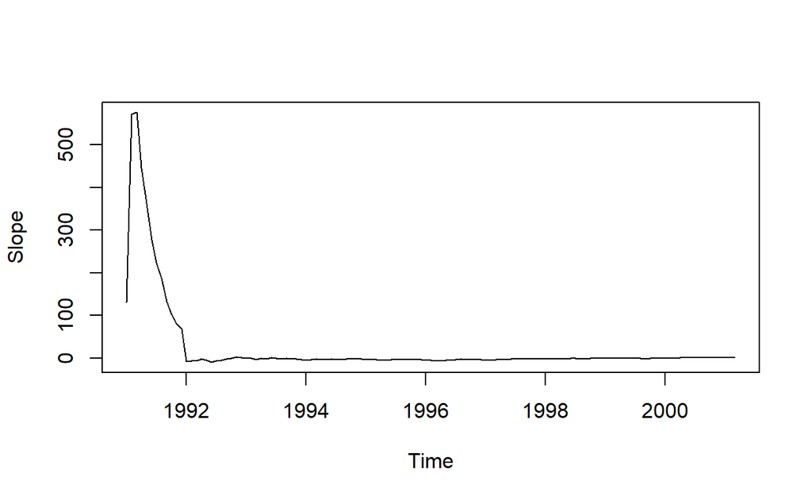

```
plot(dropFirst(filtering$m[,2]), ylab="Slope")
```

- 다음은 추정된 추세의 수준과 관측값에 대한 그래프이다.
- 앞에서 몇 시점을 제외하고는 추정된 수준은 관측값에 잘 적합된 것을 알 수 있다.

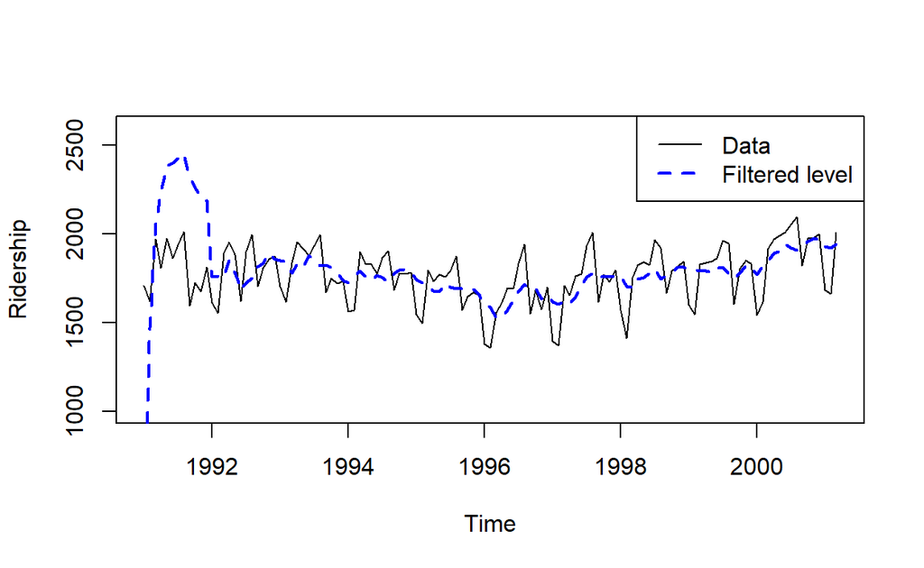

```
plot(train.ts, ylim=c(1000,2600), ylab="Ridership")
lines(dropFirst(filtering$m[,1]) ,lty=2, lwd=2, col="blue")
legend("topright", legend=c("Data", "Filtered level"), col=c("black", "blue"), lty=1:2, lwd=1:2)
```

- 다음은 kalman filtering에 의해 추정된 계절성에 대한 그래프이다.

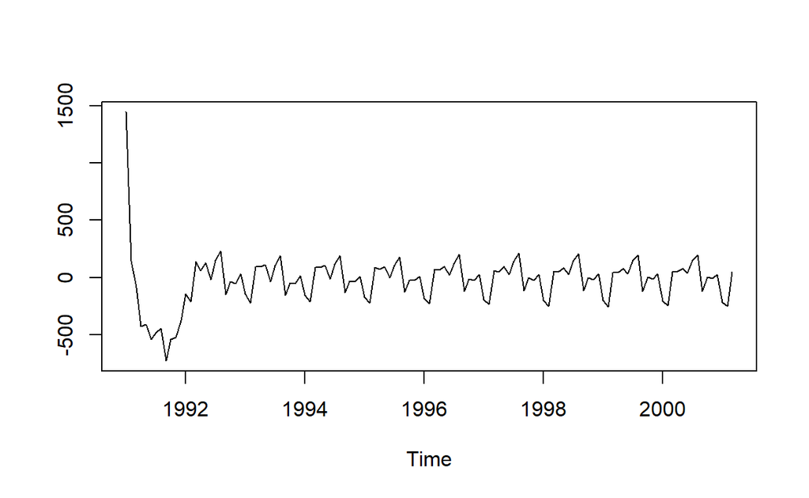

```
  plot(dropFirst(filtering$m[,3]), ylab="")
```

### **Kalman smoothing**

- `dlm` package의 `dlmSmooth()`를 이용하여 kalman smoothing을 수행할 수 있다.

```
smoothing <- dlmSmooth(filtering)   #dlmSmooth(Filted DLM)  or dlmSmooth(train.ts, modelfit1)
str(smoothing,1)
```

```
List of 3
 $ s  : Time-Series [1:124, 1:13] from 1991 to 2001: 1900 1899 1885 1878 1835 ...
 $ U.S:List of 124
 $ D.S: num [1:124, 1:13] 46.6 32.5 29.1 28.3 28 ...
```

- s : the mean of the smoothing distributions
- U.S/D.S : singular value decomposition of variance of the smoothing distributions

#### **Plot estimation for smoothing**

- 다음은 추정된 관측값과 실제 관측값에 대한 그래프이다.

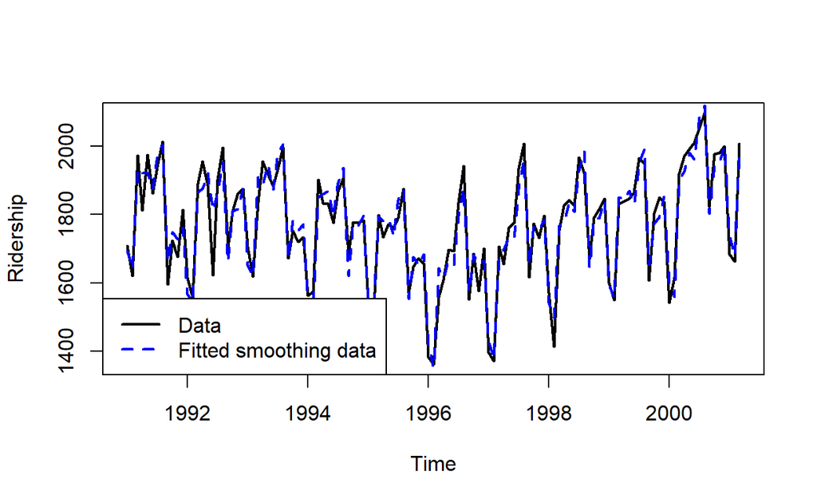

```
# Plot estimation for smoothing
# Fittited model

theta         <- modelfit1$GG%*%t(smoothing$s[1:length(train.ts),])  #s0-s[t] : Total t+1
fitted_smooth <- modelfit1$FF%*%theta

par(mfrow=c(1,1))
plot(train.ts, ylab="Ridership", lwd=2)
time <- as.vector(time(train.ts))
lines(time, fitted_smooth ,lty=2, lwd=2, col="blue")
legend("bottomleft", legend=c("Data", "Fitted smoothing data"), col=c("black", "blue"), lty=1:2, lwd=2)
```

- 다음은 kalman smoothing에 의해 추정된 추세의 수준과 기울기에 대한 그래프이다.
- 추정된 추세의 수준과 기울기는 시간에 따라 변화하는 것을 알 수 있다.

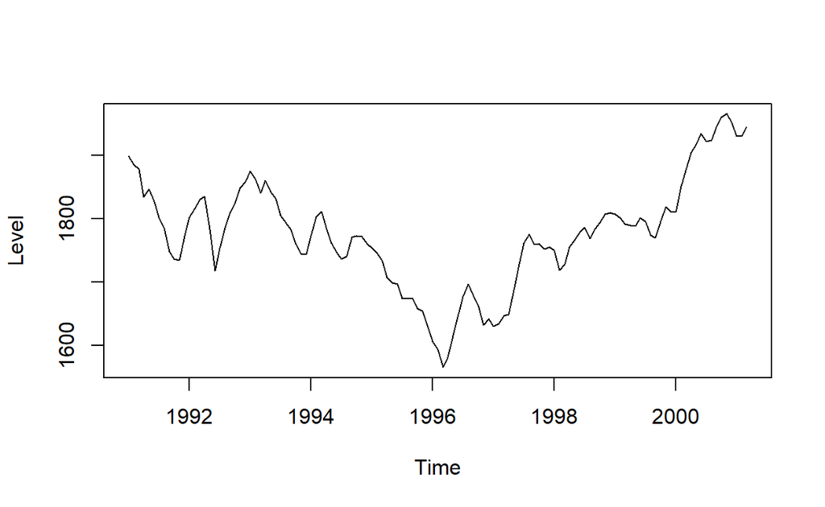

```
plot(dropFirst(smoothing$s[,1]), ylab="Level")
```

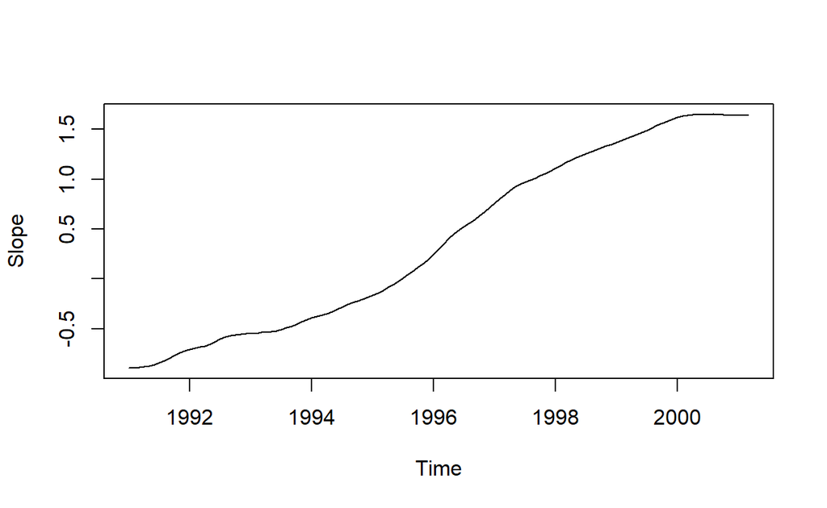

```
plot(dropFirst(smoothing$s[,2]), ylab="Slope")
```

- 다음은 추정된 추세의 수준과 관측값에 대한 그래프이다.
- Kalman filtering과 다르게 전반적으로 잘 적합된 것을 볼 수 있다.
  - Kalman smoothing은 filtering보다 더 정확하게 상태를 추정한다. 왜냐하면 smoothing은 주어진 모든 관측값을 이용하여 상태를 추정하는 반면, filtering은 과거와 현재값만을 이용하여 상태를 추정하기 때문이다.

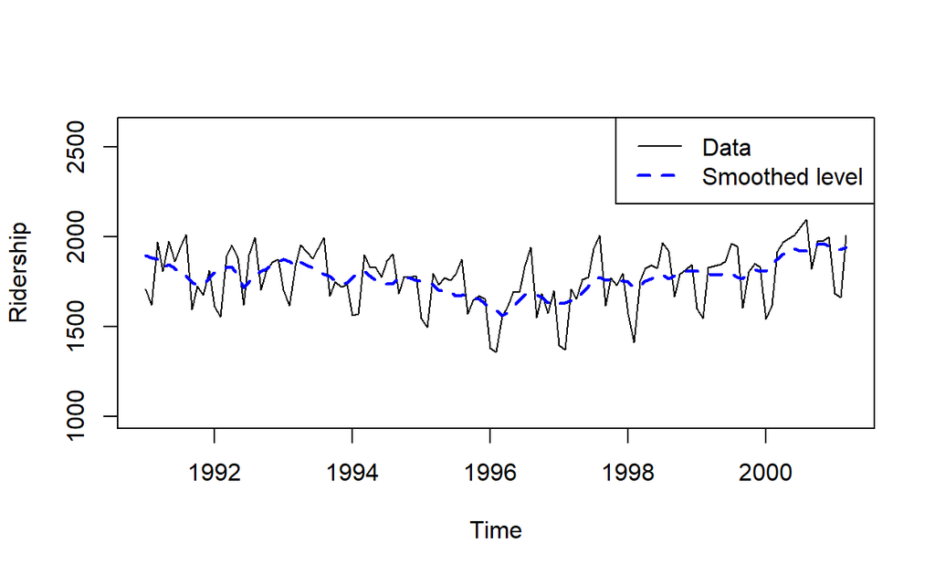

```
plot(train.ts, ylim=c(1000,2600), ylab="Ridership")
lines(dropFirst(smoothing$s[,1]) ,lty=2, lwd=2, col="blue")
legend("topright", legend=c("Data", "Smoothed level"), col=c("black", "blue"), lty=1:2, lwd=1:2)
```

- 다음은 kalman smoothing에 의해 추정된 계절성에 대한 그래프이다.

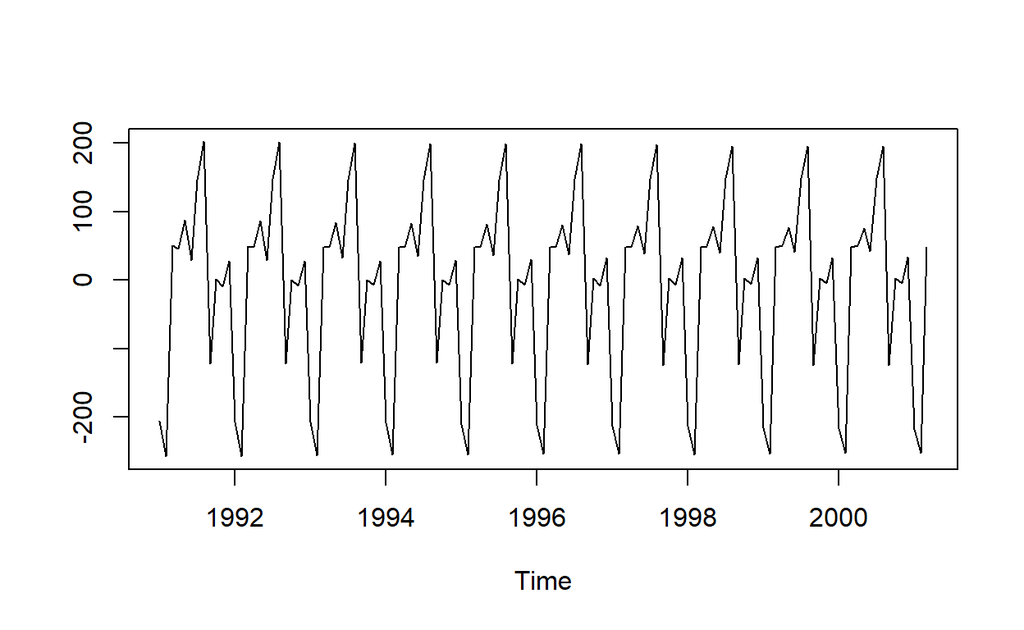

```
  plot(dropFirst(smoothing$s[,3]), ylab="")
```

## **모형 확인**

- DLM은 오차에 정규분포를 가정하기에 모형 적합 후 오차에 대한 확인이 필요하다.
- $e_{t}=Y_{t}-f_{t}$로 오차의 분포가 평균이 0인 정규분포를 따르는지, 독립인지 확인해야한다.

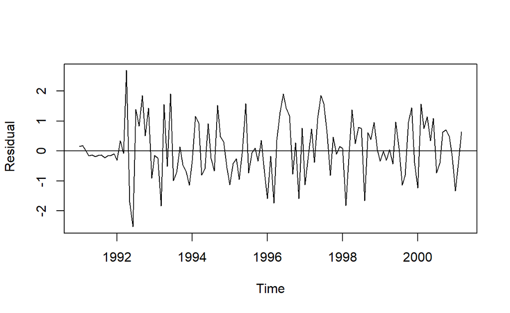

```
plot(residuals(filtering,sd = FALSE), ylab=" Residual")
abline(h=0)
```

- 0을 중심으로 무작위로 값들이 퍼져있다.

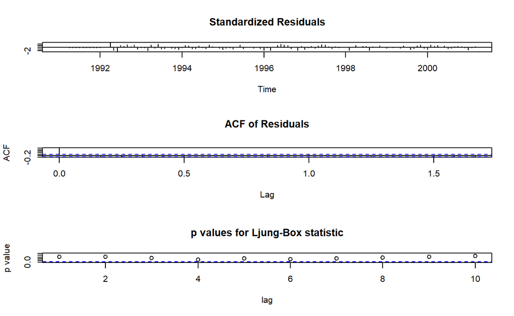

```
tsdiag(filtering, main = "Diagnostics for Regression Model")
```

- 오차들이 독립임을 알 수 있다.

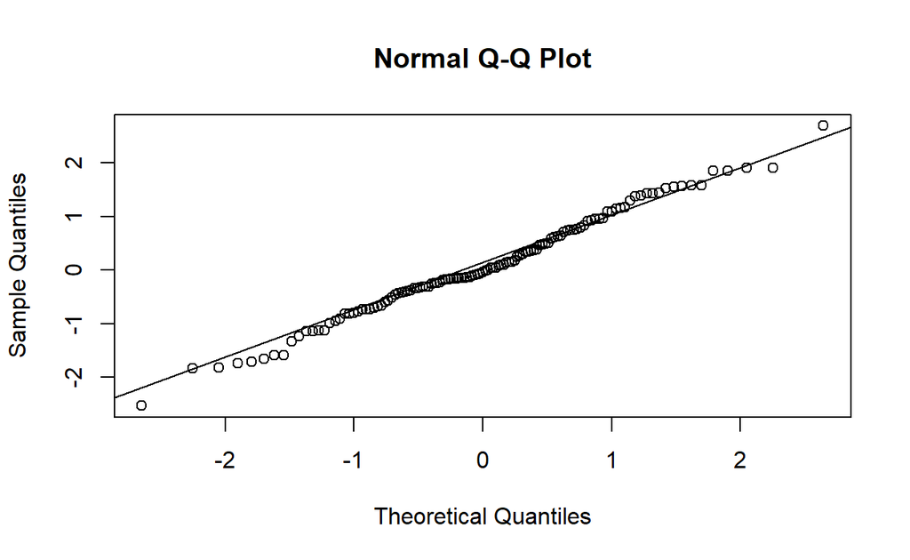

```
qqnorm(residuals(filtering, sd = FALSE))
qqline(residuals(filtering, sd = FALSE))
```

- 오차들이 정규분포를 따르는 것을 알 수 있다.

## **예측**

- `dlm` package의 `dlmForecast()`를 이용하여 예측을 수행할 수 있다.

```
forecast <- dlmForecast(filtering, nAhead = nValid)  # Forecast(filtering model)
str(forecast,1)
```

```
List of 4
 $ a: Time-Series [1:36, 1:13] from 2001 to 2004: 1946 1948 1950 1951 1953 ...
  ..- attr(*, "dimnames")=List of 2
 $ R:List of 36
 $ f: Time-Series [1:36, 1] from 2001 to 2004: 1997 2024 1992 2100 2148 ...
  ..- attr(*, "dimnames")=List of 2
 $ Q:List of 36
```

- a : the means of future state
- R : the variance of future state
- f : the means of future observations
- Q : the variance of future observations

### **Plot for forecast**

- 다음은 kalman filtering에 의하여 추정된 값과 예측값에 대한 그래프이다.

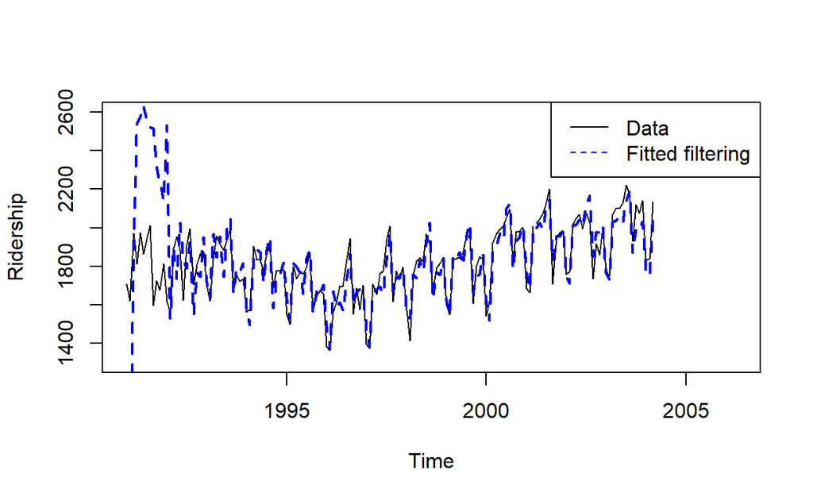

```
plot(train.ts,xlim=c(1991,2006.25), ylim=c(1300,2600), ylab="Ridership")
lines(dropFirst(filtering$f) ,lty=2, lwd=2, col="blue")
lines(valid.ts)
lines(forecast$f, lty=2,lwd=2, col="blue")
legend("topright", legend=c("Data", "Fitted filtering"), lty=1:2, col=c("black", "blue"))
```

- 앞 시점을 제외하고는 전반적으로 추정과 예측이 잘 된 것을 알 수 있다.
- 다음은 validation data에 대한 예측값과 예측구간을 나타낸 그래프이다.

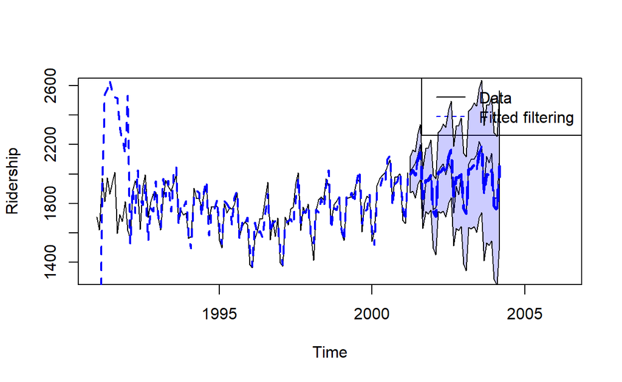

```
plot(train.ts,xlim=c(1991,2006.25), ylim=c(1300,2600), ylab="Ridership")
lines(dropFirst(filtering$f) ,lty=2, lwd=2, col="blue")
lines(valid.ts)
lines(forecast$f, lty=2,lwd=2, col="blue")
legend("topright", legend=c("Data", "Fitted filtering"), lty=1:2, col=c("black", "blue"))

# 95% confidence interval for prediction

timelo <- seq(tail(time,1) + 1/12, by = 1/12, length = nValid)
polygon(x=c(timelo, rev(timelo)), y = c(forecast$f + qnorm(0.975)*sqrt(unlist(forecast$Q)),
                                        rev(forecast$f - qnorm(0.975)*sqrt(unlist(forecast$Q)))), col=scales::alpha("blue", alpha=0.2))
lines(timelo, forecast$f, col = "blue", lwd = 3, lty=2)
```

## **회귀모형과 DLM 비교**

- 다음은 추세와 계절성을 동시에 가지는 회귀 모형과 DLM의 추정과 예측에 대한 비교 그래프이다.

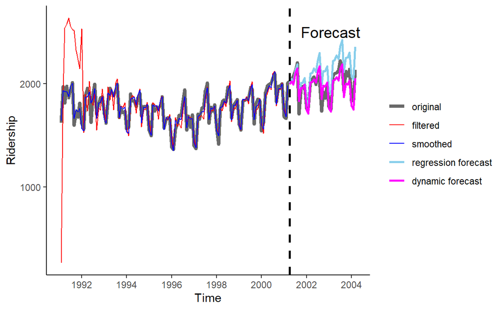

```
# Compare regression based on time-series
library(ggplot2)
library(forecast)
library(zoo)

# Regression model with Trend and Seasonality

train.lm.trend.season      <- tslm(train.ts ~ trend + I(trend^2) + season)
train.lm.trend.season.pred <- forecast(train.lm.trend.season, h=nValid, level=0)

# Data.frame

x <- index(ridership.ts)

df <- rbind(

  data.frame(x=dropFirst(x), y=dropFirst(as.numeric(ridership.ts)), series= "original"),
  data.frame(x=x[2:123], y=dropFirst(filtering$f), series="filtered"),
  data.frame(x=x[2:123], y=dropFirst(as.numeric(fitted_smooth)), series="smoothed"),
  data.frame(x=x[124:159], y=train.lm.trend.season.pred$mean, series="regression forecast" ),
  data.frame(x=x[124:159], y=c(forecast$f), series="dynamic forecast" )

   )

# Plot

ggplot(df, aes(x=x, y=y, color=series, size=series))+ geom_line() +
scale_color_manual(values = c("dimgrey", "red", "blue", "skyblue", "magenta")) +
scale_size_manual(values=c(1.5,rep(0.5,2), rep(1,2))) +
theme_classic()+
scale_x_continuous(breaks = seq(min(x)+1, max(x), by = 2)) +
geom_vline(xintercept =x[124], linetype=2, size=1, col="black") +
annotate('text', x = x[146], y = 2500, label = 'Forecast', color = 'black', size=5) +
theme(legend.title = element_blank()) +
xlab("Time")+ylab("Ridership")
```